# Assemblycomparator2 Report

2021-06-02 16:59:10

## Sample overview

|  | input_file | sample_raw | sample | extension | input_file_fasta |
| --- | --- | --- | --- | --- | --- |
| 1 | 116_2.fna | 116_2 | 116_2 | fna | output_asscom2/samples/116_2/116_2.fa |
| 2 | E8202.fna | E8202 | E8202 | fna | output_asscom2/samples/E8202/E8202.fa |
| 3 | ISMMS_VRE_1.fna | ISMMS_VRE_1 | ISMMS_VRE_1 | fna | output_asscom2/samples/ISMMS_VRE_1/ISMMS_VRE_1.fa |

## Assembly statistics

Assembly statistics is provided by assembly-stats.

|  | sample | total_length | number | mean_length | longest | shortest | N_count | Gaps | N50 | N90 |
| --- | --- | --- | --- | --- | --- | --- | --- | --- | --- | --- |
| 1 | 116_2 | 2712340 | 4 | 678085 | 2477277 | 21625 | 0 | 0 | 2477277 | 2477277 |
| 2 | E8202 | 3276455 | 7 | 468065 | 3014357 | 4203 | 0 | 0 | 3014357 | 3014357 |
| 3 | ISMMS_VRE_1 | 3259287 | 6 | 543214.5 | 3130373 | 886 | 0 | 0 | 3130373 | 3130373 |

Lengths of contigs:

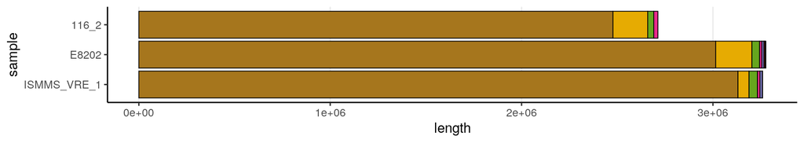

*Fig. 1: Lengths of contigs (fasta records) for each sample. The colors - only available when there is a maximum of ten contigs per sample - have no intrinsic meaning, other than highlighting the decreasing size of contigs/records in assemblies.*

## Genome annotation

Computed using the [Prokka](https://github.com/tseemann/prokka) genome annotator: *Whole genome annotation is the process of identifying features of interest in a set of genomic DNA sequences, and labelling them with useful information. Prokka is a software tool to annotate bacterial, archaeal and viral genomes quickly and produce standards-compliant output files.*

|  | sample | CDS | unique /gene codes | tRNAs | rRNAs | CRISPRs |
| --- | --- | --- | --- | --- | --- | --- |
| 1 | 116_2 | 2585 | 1166 | 68 | 18 | 0 |
| 2 | E8202 | 3180 | 1201 | 73 | 18 | 0 |
| 3 | ISMMS_VRE_1 | 3180 | 1201 | 73 | 18 | 0 |

## Species

Species identification is provided by [Kraken 2](https://github.com/DerrickWood/kraken2/wiki/About-Kraken-2).

|  | sample | percent_hit 1 | clade_hit 1 | percent_hit 2 | clade_hit 2 |
| --- | --- | --- | --- | --- | --- |
| 1 | 116_2 | 75 | Enterococcus faecium | 25 | Enterococcus faecalis |
| 2 | E8202 | 100 | Enterococcus faecium |  |  |
| 3 | ISMMS_VRE_1 | 100 | Enterococcus faecium |  |  |

Using the /project/ClinicalMicrobio/faststorage/database/kraken2/k2_pluspf_20210127 database.

## MLST

Multi locus sequence typing provided by mlst. The mlst software incorporates components of the [PubMLST](https://pubmlst.org/) database.

#### How to customize the mlst-analysis

Mlst automatically detects the best scheme for typing, one sample at a time. If you don’t agree with the automatic detection, you can enforce a single scheme across all samples by running assemblycomparator2 with the trailing command-line argument: `--config mlst_scheme=hpylori -R mlst report`. Replace *hpylori* with the mlst scheme you wish to use. You can find a full list of available schemes in the output directory in “mlst/mlst_schemes.txt”.

|  | sample | scheme | sequence_type | al. 1 | al. 2 | al. 3 | al. 4 | al. 5 | al. 6 | al. 7 |
| --- | --- | --- | --- | --- | --- | --- | --- | --- | --- | --- |
| 1 | 116_2 | efaecium | 32 | atpA(3) | ddl(3) | gdh(1) | purK(2) | gyd(1) | pstS(1) | adk(1) |
| 2 | E8202 | efaecium | 117 | atpA(9) | ddl(1) | gdh(1) | purK(1) | gyd(1) | pstS(1) | adk(1) |
| 3 | ISMMS_VRE_1 | efaecium | - | atpA(7) | ddl(1) | gdh(1) | purK(1) | gyd(5) | pstS(1) | adk(~1) |

## Resistance

### NCBI Resistance

Resistance genes provided by [NCBI AMRFinder](https://www.ncbi.nlm.nih.gov/pmc/articles/PMC6811410/) via [Abricate](https://github.com/tseemann/abricate#abricate).

|  | sample | num_found | aac(6')-Ii | aacA-ENT1 | ant(6)-Ia | aph(2'')-Ih | aph(3')-IIIa | dfrF | dfrG | eat(A) | erm(B) | erm(T) | fosB3 | msr(C) | poxtA | sat4 | tet(L) | tet(M) | vanA | vanH-A | vanR-A | vanS-A | vanX-A | vanY-A | vanZ-A |
| --- | --- | --- | --- | --- | --- | --- | --- | --- | --- | --- | --- | --- | --- | --- | --- | --- | --- | --- | --- | --- | --- | --- | --- | --- | --- |
| 1 | 116_2 | 7 | 100.00 | . | . | 88.70 | . | . | . | 100 | 100 | . | 100.00 | 100 | 100.00 | . | . | . | . | . | . | . | . | . | . |
| 2 | E8202 | 11 | . | 100.00 | . | . | . | 100.00 | 100.00 | 100 | 88.89 | . | . | 100 | . | . | . | . | 100.00 | 100.00 | 100.00 | 100.00 | 100.00 | . | . |
| 3 | ISMMS_VRE_1 | 19 | . | 100.00 | 100.00 | 89.15;89.15 | 100.00 | . | 100.00 | 100 | 100 | 100.00 | . | 100 | . | 99.82 | 97.53 | 100.00 | 100.00 | 100.00 | 100.00 | 100.00 | 100.00 | 100.00 | 100.00 |

### Card Resistance genes

Resistance genes provided by The Comprehensive Antibiotic Resistance Database ([Card](https://card.mcmaster.ca/)) via abricate.

|  | sample | num_found | AAC(6')-Ie-APH(2'')-Ia | AAC(6')-Ii | APH(3')-IIIa | ErmB | ErmT | FosB3 | SAT-4 | aad(6) | dfrF | dfrG | efmA | msrC | poxtA | tet(L) | tetM | vanA | vanHA | vanRA | vanSA | vanXA | vanYA | vanZA |
| --- | --- | --- | --- | --- | --- | --- | --- | --- | --- | --- | --- | --- | --- | --- | --- | --- | --- | --- | --- | --- | --- | --- | --- | --- |
| 1 | 116_2 | 7 | 99.51 | 100 | . | 99.87 | . | 100.00 | . | . | . | . | 100 | 100 | 100.00 | . | . | . | . | . | . | . | . | . |
| 2 | E8202 | 11 | . | 100 | . | 87.82 | . | . | . | . | 100.00 | 100.00 | 100 | 100 | . | . | . | 100.00 | 100.00 | 100.00 | 100.00 | 100.00 | . | . |
| 3 | ISMMS_VRE_1 | 19 | 100.00;100.00 | 100 | 100.00 | 99.87 | 100.00 | . | 99.82 | 100.00 | . | 100.00 | 100 | 100 | . | 97.53 | 100.00 | 100.00 | 100.00 | 100.00 | 100.00 | 100.00 | 100.00 | 100.00 |

### Plasmidfinder calls

Plasmid calls provided by [PlasmidFinder](https://cge.cbs.dtu.dk/services/PlasmidFinder/) via abricate.

|  | sample | num_found | rep14a_3_EFAU085p5001(AUS0085p5) | rep17_1_CDS29(pRUM) | rep18a_1_repA(p200B) | rep18b_1_BO23315710(pE1p13) | rep1_9_repE(pKL0018) | rep22_1b_repB(pAMalpha1) | rep29_2_EFAU085p4001(Aus0085p4)_Aus0085 | rep2_1_orf1(pRE25) | rep35_2_ORF2(pSMQ172) | repUS15_1_repA(DO3) | repUS15_2_repA(pNB2354p1) | repUS43_1_CDS12738(DOp1) | repUS56_1_EFA0012(pTEF1) |
| --- | --- | --- | --- | --- | --- | --- | --- | --- | --- | --- | --- | --- | --- | --- | --- |
| 1 | 116_2 | 3 | . | . | . | . | 100.00 | . | 99.86 | . | . | . | 100.00 | . | . |
| 2 | E8202 | 5 | . | . | . | 100.00 | . | . | 100.00 | 100.00 | 97.62 | 100.00 | . | . | . |
| 3 | ISMMS_VRE_1 | 7 | 97.44 | 100.00 | 100.00;100.00 | . | . | 87.26 | . | . | . | . | 100.00 | 100.00 | 100.00 |

### VFDB calls

Virulence factor calls provided by The virulence factor database ([VFDB](http://www.mgc.ac.cn/VFs/main.htm)) via abricate. “An integrated and comprehensive online resource for curating information about virulence factors of bacterial pathogens.”

|  | sample | num_found | acm | ecbA | fss3 | scm | sgrA |
| --- | --- | --- | --- | --- | --- | --- | --- |
| 1 | 116_2 | 2 | 100 | . | . | 97.13 | . |
| 2 | E8202 | 4 | 100 | 100.00 | 98.23 | . | 100.00 |
| 3 | ISMMS_VRE_1 | 4 | 100 | . | 98.27 | 100.00 | 100.00 |

## Pan and Core genome

[Roary](https://sanger-pathogens.github.io/Roary/) the pan genome pipeline computes the number of orthologous genes in a number of core/pan partitions.

The core genome denotes the genes which are conserved between all samples (intersection), whereas the pan genome is the union of all genes across all samples.

| ortholog class | definition | count |
| --- | --- | --- |
| Core genes | (99% &lt;= strains &lt;= 100%) | 2107 |
| Soft core genes | (95% &lt;= strains &lt; 99%) | 0 |
| Shell genes | (15% &lt;= strains &lt; 95%) | 2094 |
| Cloud genes | (0% &lt;= strains &lt; 15%) | 0 |
| Total genes | (0% &lt;= strains &lt;= 100%) | 4201 |

*Table 1: Distribution of genes in different core/pan partitions.*

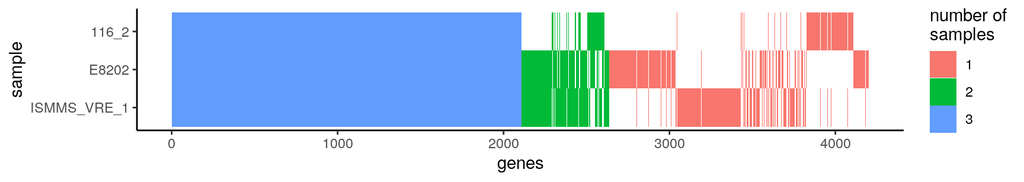

*Fig. 2: Visual distribution of genes in the different samples. The genes are ordered in respect to the number of samples sharing them.*

## Core genome phylogeny

The core genome phylogeny is provided with [FastTree](http://www.microbesonline.org/fasttree/) with the generalized time-reversible (GTR) model of nucleotide evolution. The plotted tree is not rooted.

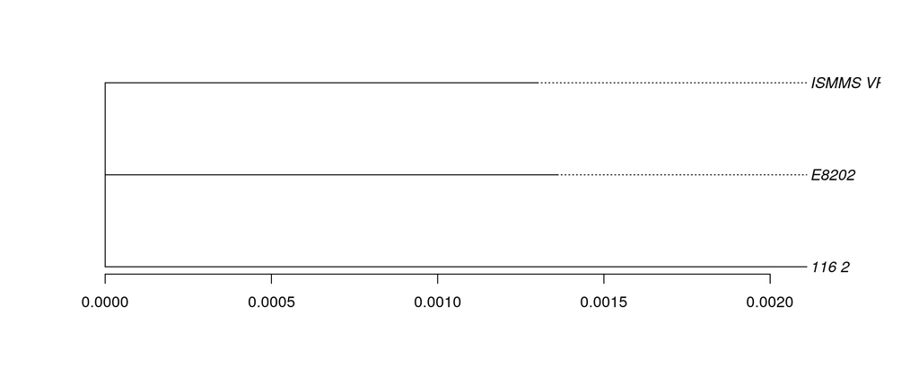

SNP-distances between the core gene alignment. Calculated with snp-dists. The shown table is symmetrical around the diagonal.

|  | sample | 116_2 | E8202 | ISMMS_VRE_1 |
| --- | --- | --- | --- | --- |
| 1 | 116_2 | 0 | 6116 | 6023 |
| 2 | E8202 | 6116 | 0 | 4684 |
| 3 | ISMMS_VRE_1 | 6023 | 4684 | 0 |

*Table 2: Pairwise distances between the samples in the core genome.*

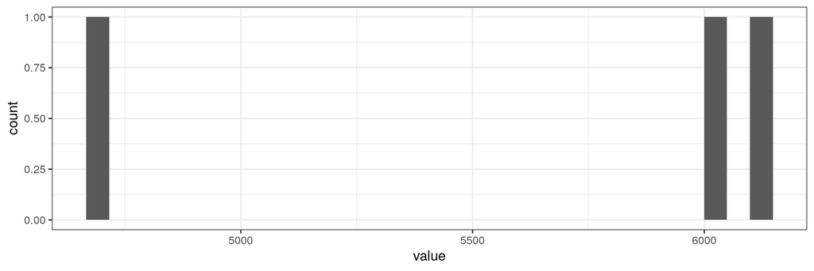

*Fig. 4: Pairwise distances between the samples in the core genome.*

## Mashtree phylogeny

Mashtree is developed by Lee S. Katz and extends the minhash distance technique. If the core genome of the samples is small, absent, or otherwise not representative of the collection of assemblies you wish to compare, mashtree might be informative on the overall taxonomic clusters. Please be aware that the tree is not rooted.

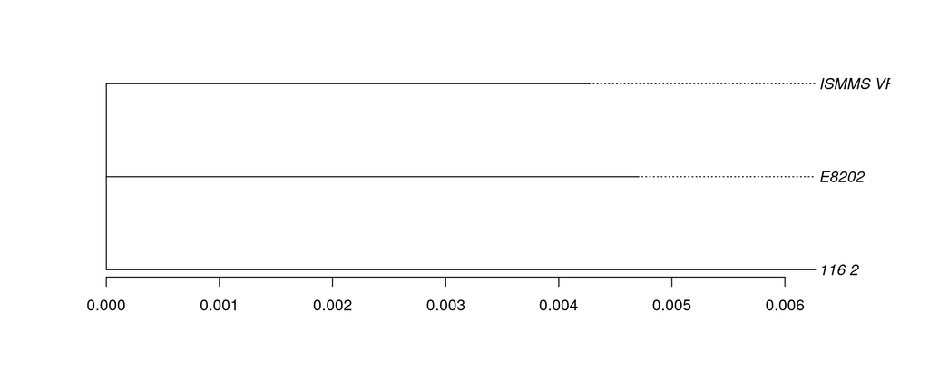

*Fig. 5: Approximation of a phylogenetic tree calculated with mashtree.*

The assemblycomparator2 pipeline and report is developed by [Oliver Hansen](https://github.com/oliverh2020) & [Carl M. Kobel](https://github.com/cmkobel)